# **Detecting Malaria Parasites in Blood Smear Microscopy**

### ❓ Key Questions — Final Insights

> **Q: Can the model be made interpretable enough for clinical staff to trust it? A black-box classifier that says "parasitized" without showing *why* is difficult to adopt in a diagnostic workflow.**

> Recommended solution: Apply **Grad-CAM** (Gradient-weighted Class Activation Mapping) to produce a heatmap overlaid on the input image highlighting which pixels most influenced the prediction. If the heatmap consistently focuses on the parasite stain region, clinicians can verify that the model is reasoning correctly rather than exploiting spurious correlations (e.g. background colour). If the heatmap focuses on cell borders or background, the model is likely not using the right features and needs retraining.

```
[grad-cam] using best Keras model: EfficientNetB3
```

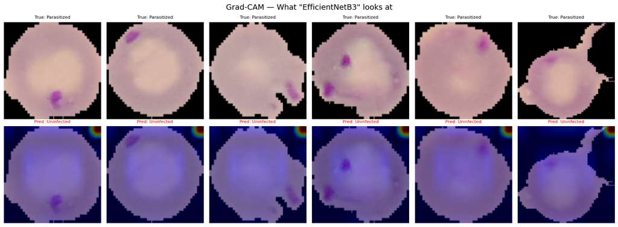

**How to interpret Grad-CAM results:**

| Heatmap focus | Interpretation | Action |
| --- | --- | --- |
| Centre of cell, stain region | ✅ Model uses correct features | Deploy with confidence |
| Cell border / membrane only | ⚠️ Possible shape bias | Add more morphological augmentation |
| Background or slide artefacts | ❌ Spurious correlation | Retrain with background-cropped images |
| Diffuse / no clear focus | ❓ Model is uncertain | Lower confidence threshold, flag for review |

```python
# tensorflow as tf, numpy as np, matplotlib.pyplot as plt
#   →  all already imported in earlier cells

# Auto-select the "best" Keras model from whatever has been trained. We pick
# by lowest test loss (consistent with the ranked-summary winner rule), with
# graceful fallbacks. Earlier drafts hard-coded `best_model`, which raised
# `NameError: name 'best_model' is not defined` on every run.
_candidate_specs = [
    # (display, model var,        loss var,       acc var)
    ('Base',           'base_model', 'base_loss',  'base_acc'),
    ('Deeper',         'model1',     'loss1',      'acc1'),
    ('BN+LReLU',       'model2',     'loss2',      'acc2'),
    ('Augmented',      'model3',     'loss3',      'acc3'),
    ('VGG16',          'vgg_model',  'vgg_loss',   'vgg_acc'),
    ('EfficientNetB0', 'effb0',      'effb0_loss', 'effb0_acc'),
    ('EfficientNetB3', 'effb3',      'effb3_loss', 'effb3_acc'),
    ('ResNet50V2',     'rn50',       'rn50_loss',  'rn50_acc'),
    ('MobileNetV3L',   'mnv3',       'mnv3_loss',  'mnv3_acc'),
]
_g = globals()
_candidates = []
for label, mvar, lvar, avar in _candidate_specs:
    m = _g.get(mvar)
    if m is None or not hasattr(m, 'layers'):
        continue
    loss = _g.get(lvar)
    acc  = _g.get(avar)
    # Sort key: lower loss first, then higher accuracy. Missing loss → +inf
    # so it sinks below any model with a real loss value.
    sort_key = (float('inf') if loss is None else float(loss),
                -float(acc) if acc is not None else 0.0)
    _candidates.append((sort_key, label, m))

if not _candidates:
    raise RuntimeError(
        "Grad-CAM needs a trained Keras model in scope. None of base_model, "
        "model1..3, vgg_model, effb0/effb3/rn50/mnv3 are defined yet."
    )
_candidates.sort(key=lambda x: x[0])
_best_label = _candidates[0][1]
best_model  = _candidates[0][2]
print(f"[grad-cam] using best Keras model: {_best_label}")

def make_gradcam_heatmap(*, image: np.ndarray, model, last_conv_layer: str):
    grad_model = tf.keras.models.Model(
        inputs=model.inputs,
        outputs=[model.get_layer(last_conv_layer).output, model.output]
    )
    with tf.GradientTape() as tape:
        # NOTE: refer to the function parameter `image`, not an undefined `img_array`.
        conv_outputs, predictions = grad_model(image)
        pred_class = tf.argmax(predictions[0])
        loss = predictions[:, pred_class]

    grads       = tape.gradient(loss, conv_outputs)
    pooled_grads = tf.reduce_mean(grads, axis=(0, 1, 2))
    conv_outputs = conv_outputs[0]
    heatmap      = conv_outputs @ pooled_grads[..., tf.newaxis]
    heatmap      = tf.squeeze(heatmap)
    heatmap      = tf.maximum(heatmap, 0) / (tf.math.reduce_max(heatmap) + 1e-8)
    return heatmap.numpy(), class_names[pred_class.numpy()]

def overlay_gradcam(*, image: np.ndarray, heatmap: np.ndarray, alpha: float = 0.4) -> np.ndarray:
    heatmap_resized = cv2.resize(heatmap, (image.shape[1], image.shape[0]))
    heatmap_color   = cv2.applyColorMap(
        np.uint8(255 * heatmap_resized), cv2.COLORMAP_JET
    )
    heatmap_color = cv2.cvtColor(heatmap_color, cv2.COLOR_BGR2RGB)
    overlay = (image * 255 * (1 - alpha) + heatmap_color * alpha).astype(np.uint8)
    return overlay

# Find the last Conv2D layer in the chosen model. For pretrained backbones
# wrapped as a single sub-Model layer (e.g. VGG16), recurse into its layers.
def _last_conv_name(model):
    for layer in reversed(model.layers):
        if isinstance(layer, tf.keras.layers.Conv2D):
            return layer.name
        if hasattr(layer, 'layers'):
            nested = [l.name for l in layer.layers
                      if isinstance(l, tf.keras.layers.Conv2D)]
            if nested:
                return nested[-1]
    return None

last_conv = _last_conv_name(best_model)
if last_conv is None:
    raise RuntimeError(
        f"Could not find a Conv2D layer inside `{_best_label}`. "
        "Grad-CAM requires a convolutional layer to inspect."
    )

# Match the model's expected input HxW. test_images_norm is at IMG_SIZE×IMG_SIZE
# but a Part 5 backbone may want 224 or 300. Resize per-image with cv2.
_model_h = best_model.input_shape[1] or test_images_norm.shape[1]
_model_w = best_model.input_shape[2] or test_images_norm.shape[2]

fig, axes = plt.subplots(2, 6, figsize=(16, 6))
fig.suptitle(f'Grad-CAM — What "{_best_label}" looks at', fontsize=14)

for col, idx in enumerate(range(6)):
    img = test_images_norm[idx]
    # Resize for the model if it expects a different spatial size.
    if (_model_h, _model_w) != (img.shape[0], img.shape[1]):
        img_for_model = cv2.resize(img, (_model_w, _model_h))
    else:
        img_for_model = img
    input_arr = np.expand_dims(img_for_model.astype('float32'), axis=0)
    heatmap, pred_label = make_gradcam_heatmap(
        image=input_arr, model=best_model, last_conv_layer=last_conv)
    overlay = overlay_gradcam(image=img, heatmap=heatmap)
    true_label = class_names[test_labels[idx]]

    axes[0, col].imshow(img)
    axes[0, col].set_title(f'True: {true_label}', fontsize=8)
    axes[0, col].axis('off')

    axes[1, col].imshow(overlay)
    axes[1, col].set_title(f'Pred: {pred_label}', fontsize=8,
                            color='green' if pred_label == true_label else 'red')
    axes[1, col].axis('off')

plt.tight_layout()
plt.show()

say(this="""
**How to interpret Grad-CAM results:**

| Heatmap focus | Interpretation | Action |
|---------------|----------------|--------|
| Centre of cell, stain region | ✅ Model uses correct features | Deploy with confidence |
| Cell border / membrane only  | ⚠️ Possible shape bias | Add more morphological augmentation |
| Background or slide artefacts | ❌ Spurious correlation | Retrain with background-cropped images |
| Diffuse / no clear focus      | ❓ Model is uncertain | Lower confidence threshold, flag for review |
""")
```